# Another Two-Way ANOVA Example

Finally, to determine which section had significantly more ad inquiries, we do a Tukey HSD post-hoc analysis on the Monday and Thursday data subsets.

```r
TukeyHSD(mon.aov)
```

```
##   Tukey multiple comparisons of means
##     95% family-wise confidence level
##
## Fit: aov(formula = inquiries ~ section, data = Mon_ads)
##
## $section
##                  diff        lwr        upr     p adj
## News-Business   -3.25  -6.388851 -0.1111488 0.0428536
## Sports-Business -7.00 -10.138851 -3.8611488 0.0004043
## Sports-News     -3.75  -6.888851 -0.6111488 0.0214752
```

```r
TukeyHSD(thu.aov)
```

```
##   Tukey multiple comparisons of means
##     95% family-wise confidence level
##
## Fit: aov(formula = inquiries ~ section, data = Thu_ads)
##
## $section
##                  diff        lwr        upr     p adj
## News-Business   -3.50 -5.5283451 -1.4716549 0.0024493
## Sports-Business -1.75 -3.7783451  0.2783451 0.0906099
## Sports-News      1.75 -0.2783451  3.7783451 0.0906099
```

On Mondays, the difference in average number of ad inquiries is significant between the Business section (*M* = 11.50) and Sports section (*M* = 4.50). There was no significant difference for the News section.

On Thursdays, the difference in average number of ad inquiries is significant between the News section (*M* = 4.25) and the Business section (*M* = 7.75). There was no significant difference in the Sports section.

Then, we perform similar analysis to determine **simple effects** for the other factor, the **days of the week**. Here, to control for Type I error, we will adjust $\alpha$ by dividing by the number of levels in the factor we are examining (.05/3 = .0167).

```r
news_ads = subset(ads, section == "News")
bus_ads = subset(ads, section == "Business")
sport_ads = subset(ads, section == "Sports")

head(news_ads)
```

```
##    weekday section inquiries
## 1   Monday    News        11
## 4   Monday    News         8
## 7   Monday    News         6
## 10  Monday    News         8
## 13 Tuesday    News         9
## 16 Tuesday    News        10
```

```r
news.aov <- aov(inquiries~weekday, data = news_ads)
bus.aov <- aov(inquiries~weekday, data = bus_ads)
sport.aov <- aov(inquiries~weekday, data = sport_ads)

summary(news.aov); summary(bus.aov); summary(sport.aov)
```

```
##             Df Sum Sq Mean Sq F value   Pr(>F)
## weekday      4  147.8   36.95   18.48 1.16e-05 ***
## Residuals   15   30.0    2.00
## ---
## Signif. codes:  0 '***' 0.001 '**' 0.01 '*' 0.05 '.' 0.1 ' ' 1
```

```
##             Df Sum Sq Mean Sq F value Pr(>F)
## weekday      4   32.3   8.075    4.75 0.0112 *
## Residuals   15   25.5   1.700
## ---
## Signif. codes:  0 '***' 0.001 '**' 0.01 '*' 0.05 '.' 0.1 ' ' 1
```

```
##             Df Sum Sq Mean Sq F value   Pr(>F)
## weekday      4  102.5  25.625   16.36 2.41e-05 ***
## Residuals   15   23.5   1.567
## ---
## Signif. codes:  0 '***' 0.001 '**' 0.01 '*' 0.05 '.' 0.1 ' ' 1
```

All three subset ANOVAs are statistically significant, meaning a Tukey HSD post-hoc analysis is needed to determine which days of the week have the significantly different number of ad inquiries in each section.

```r
TukeyHSD(news.aov)
```

```
##   Tukey multiple comparisons of means
##     95% family-wise confidence level
##
## Fit: aov(formula = inquiries ~ weekday, data = news_ads)
##
## $weekday
##                     diff        lwr        upr     p adj
## Monday-Friday      -4.25  -7.337924 -1.1620755 0.0053590
## Thursday-Friday    -8.25 -11.337924 -5.1620755 0.0000051
## Tuesday-Friday     -2.25  -5.337924  0.8379245 0.2147081
## Wednesday-Friday   -3.25  -6.337924 -0.1620755 0.0368848
## Thursday-Monday    -4.00  -7.087924 -0.9120755 0.0087044
## Tuesday-Monday      2.00  -1.087924  5.0879245 0.3121688
## Wednesday-Monday    1.00  -2.087924  4.0879245 0.8513270
## Tuesday-Thursday    6.00   2.912076  9.0879245 0.0002030
## Wednesday-Thursday  5.00   1.912076  8.0879245 0.0012728
## Wednesday-Tuesday  -1.00  -4.087924  2.0879245 0.8513270
```

```r
TukeyHSD(bus.aov)
```

```
##   Tukey multiple comparisons of means
##     95% family-wise confidence level
##
## Fit: aov(formula = inquiries ~ weekday, data = bus_ads)
##
## $weekday
##                     diff        lwr         upr     p adj
## Monday-Friday       2.50 -0.3469257  5.34692571 0.0990930
## Thursday-Friday    -1.25 -4.0969257  1.59692571 0.6628312
## Tuesday-Friday     -0.25 -3.0969257  2.59692571 0.9986705
## Wednesday-Friday   -0.50 -3.3469257  2.34692571 0.9812560
## Thursday-Monday    -3.75 -6.5969257 -0.90307429 0.0076361
## Tuesday-Monday     -2.75 -5.5969257  0.09692571 0.0607443
## Wednesday-Monday   -3.00 -5.8469257 -0.15307429 0.0366098
## Tuesday-Thursday    1.00 -1.8469257  3.84692571 0.8115642
## Wednesday-Thursday  0.75 -2.0969257  3.59692571 0.9224100
## Wednesday-Tuesday  -0.25 -3.0969257  2.59692571 0.9986705
```

```r
TukeyHSD(sport.aov)
```

```
##   Tukey multiple comparisons of means
##     95% family-wise confidence level
##
## Fit: aov(formula = inquiries ~ weekday, data = sport_ads)
##
## $weekday
##                     diff        lwr       upr     p adj
## Monday-Friday      -6.75 -9.4830022 -4.016998 0.0000133
## Thursday-Friday    -5.25 -7.9830022 -2.516998 0.0002293
## Tuesday-Friday     -4.75 -7.4830022 -2.016998 0.0006408
## Wednesday-Friday   -4.50 -7.2330022 -1.766998 0.0010856
## Thursday-Monday     1.50 -1.2330022  4.233002 0.4656190
## Tuesday-Monday      2.00 -0.7330022  4.733002 0.2114497
## Wednesday-Monday    2.25 -0.4830022  4.983002 0.1329700
## Tuesday-Thursday    0.50 -2.2330022  3.233002 0.9782383
## Wednesday-Thursday  0.75 -1.9830022  3.483002 0.9113265
## Wednesday-Tuesday   0.25 -2.4830022  2.983002 0.9984402
```

In the News section, the number of inquiries is significantly lowest on Thursdays (*M* = 4.25). The number of ads on Mondays are significantly more than Thursdays (*M* = 8.25). And Fridays have significantly more inquiries than Mondays and Thursdays (*M* = 12.5).

In the Business section, only Mondays (*M* = 11.5) are significantly different from Thursdays (*M* = 7.75) in terms of average number of ad inquiries.

In the Sports section, the ad inquiries on Fridays (*M* = 11.25) are significantly greater than Mondays (*M* = 4.5), Tuesdays (*M* = 6.5), Wednesdays (*M* = 6.75), and Thursdays (*M* = 6.0). The other days of the week did not have a significant difference.

Returning to look at the interaction plot:

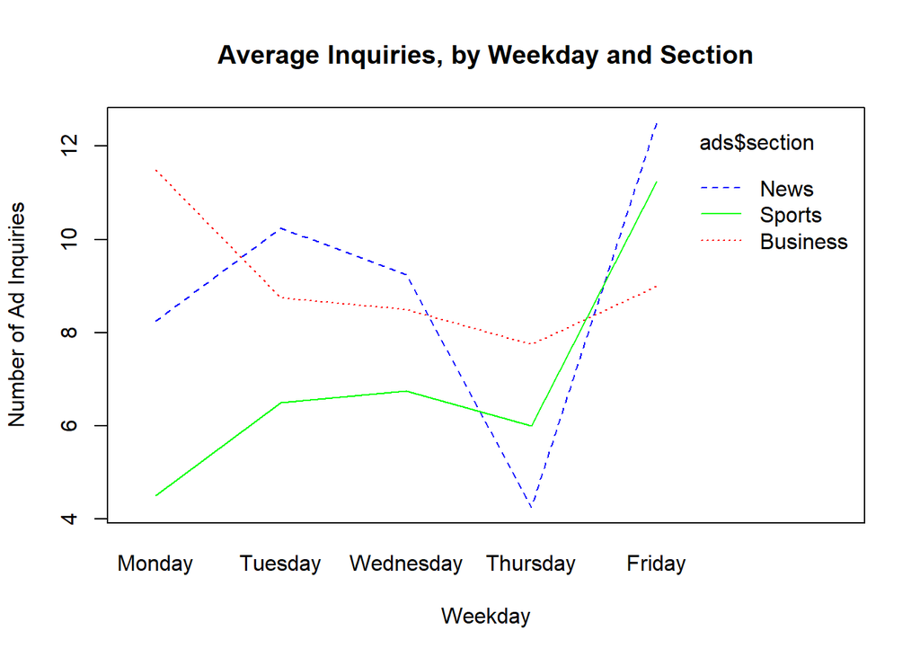

```r
interaction.plot(day_ord, ads$section, ads$inquiries,
                 xlab="Weekday", ylab="Number of Ad Inquiries",
                 col = c("red", "blue", "green"),
                 main="Average Inquiries, by Weekday and Section")
```

The difference in number of ad inquiries by section is most significant on Mondays and Thursdays, with Business greater than Sports on Mondays and Business greater than News on Thursdays.